# Soluzione Esercizi

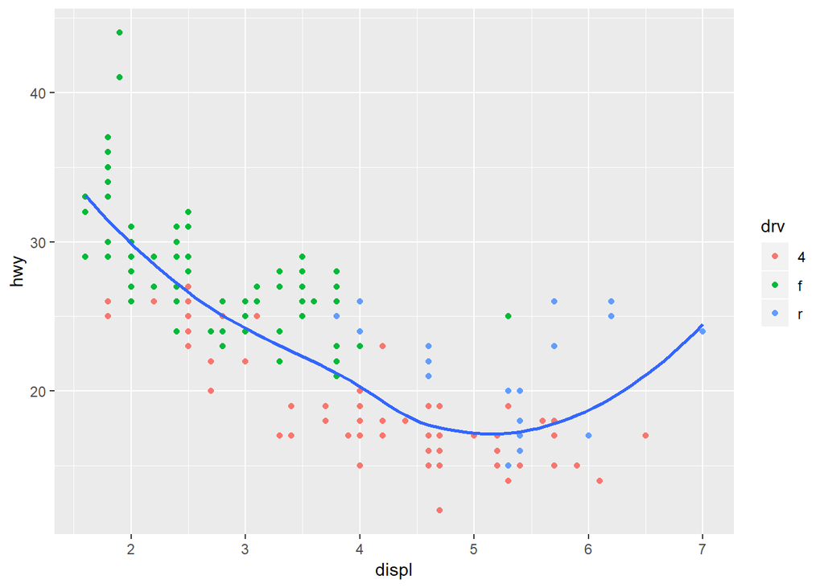

```r
ggplot(data = mpg, aes(x = displ, y = hwy)) +
  geom_point(aes(col=drv)) +
  geom_smooth(se = FALSE)
## `geom_smooth()` using method = 'loess' and formula 'y ~ x'
```

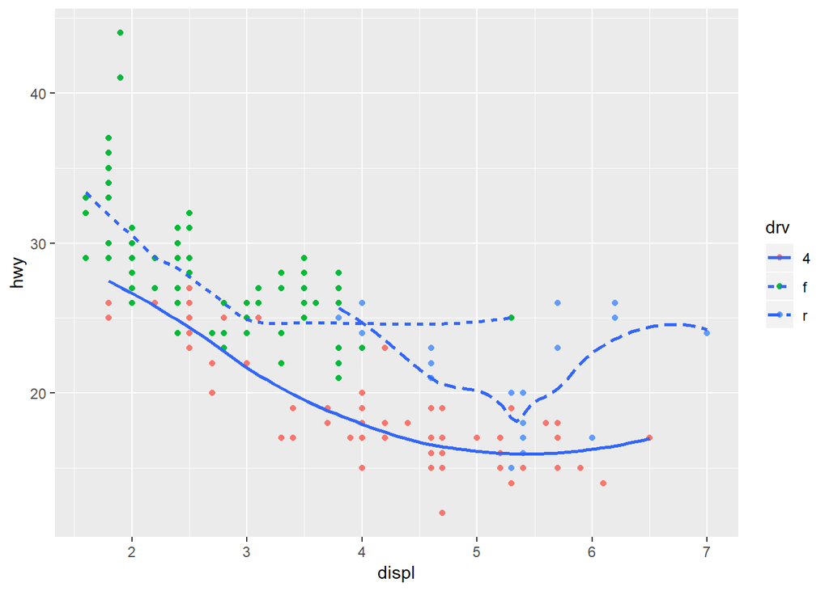

```r
ggplot(data = mpg, aes(x = displ, y = hwy)) +
  geom_point(aes(col=drv)) +
  geom_smooth(aes(group = drv, linetype=drv), se = FALSE)
## `geom_smooth()` using method = 'loess' and formula 'y ~ x'
```

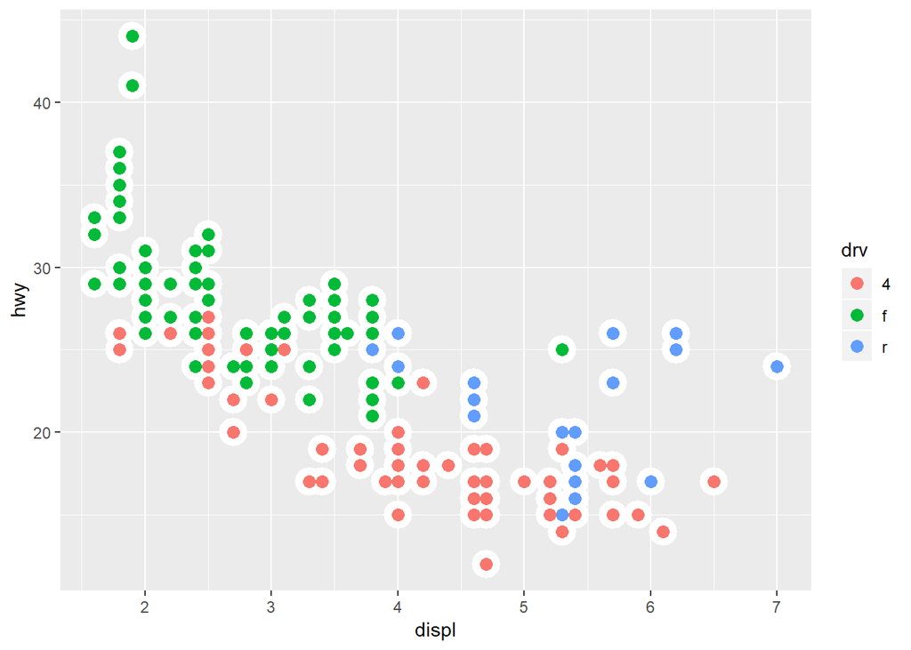

```r
ggplot(data = mpg, aes(x = displ, y = hwy)) +
  geom_point(stroke = 4.5, col = "white") +
  geom_point(aes(col=drv), size = 3)
```

## dataframe

Esercizi sui dataframe

2. Caricate il dataframe mtcars e stampatelo a schermo. Data la lunghezza dell’output evito di stamparlo a schermo.

```r
data("mtcars", package = "datasets")
```

3. Stampare a schermo la struttura del dataframe, le prime 6 righe e le ultime 6.

```r
str(mtcars)
```

```
## 'data.frame':    32 obs. of  11 variables:
##  $ mpg : num  21 21 22.8 21.4 18.7 18.1 14.3 24.4 22.8 19.2 ...
##  $ cyl : num  6 6 4 6 8 6 8 4 4 6 ...
##  $ disp: num  160 160 108 258 360 ...
##  $ hp  : num  110 110 93 110 175 105 245 62 95 123 ...
##  $ drat: num  3.9 3.9 3.85 3.08 3.15 2.76 3.21 3.69 3.92 3.92 ...
##  $ wt  : num  2.62 2.88 2.32 3.21 3.44 ...
##  $ qsec: num  16.5 17 18.6 19.4 17 ...
##  $ vs  : num  0 0 1 1 0 1 0 1 1 1 ...
##  $ am  : num  1 1 1 0 0 0 0 0 0 0 ...
##  $ gear: num  4 4 4 3 3 3 3 4 4 4 ...
##  $ carb: num  4 4 1 1 2 1 4 2 2 4 ...
```

```r
head(mtcars)
```

```
##                    mpg cyl disp  hp drat    wt  qsec vs am gear carb
## Mazda RX4         21.0   6  160 110 3.90 2.620 16.46  0  1    4    4
## Mazda RX4 Wag     21.0   6  160 110 3.90 2.875 17.02  0  1    4    4
## Datsun 710        22.8   4  108  93 3.85 2.320 18.61  1  1    4    1
## Hornet 4 Drive    21.4   6  258 110 3.08 3.215 19.44  1  0    3    1
## Hornet Sportabout 18.7   8  360 175 3.15 3.440 17.02  0  0    3    2
## Valiant           18.1   6  225 105 2.76 3.460 20.22  1  0    3    1
```

```r
tail(mtcars)
```

```
##                 mpg cyl  disp  hp drat    wt qsec vs am gear carb
## Porsche 914-2  26.0   4 120.3  91 4.43 2.140 16.7  0  1    5    2
## Lotus Europa   30.4   4  95.1 113 3.77 1.513 16.9  1  1    5    2
## Ford Pantera L 15.8   8 351.0 264 4.22 3.170 14.5  0  1    5    4
## Ferrari Dino   19.7   6 145.0 175 3.62 2.770 15.5  0  1    5    6
## Maserati Bora  15.0   8 301.0 335 3.54 3.570 14.6  0  1    5    8
## Volvo 142E     21.4   4 121.0 109 4.11 2.780 18.6  1  1    4    2
```

4. Stampate a schermo il numero di righe del dataframe, il nome delle colonne ed il summary.

```r
dim(mtcars)[1]
```

```
## [1] 32
```

```r
# equivalentemente si poteva fare nrow(mtcars)

names(mtcars)
```

```
##  [1] "mpg"  "cyl"  "disp" "hp"   "drat" "wt"   "qsec" "vs"   "am"   "gear"
## [11] "carb"
```

```r
summary(mtcars)
```

```
##       mpg             cyl             disp             hp
##  Min.   :10.40   Min.   :4.000   Min.   : 71.1   Min.   : 52.0
##  1st Qu.:15.43   1st Qu.:4.000   1st Qu.:120.8   1st Qu.: 96.5
##  Median :19.20   Median :6.000   Median :196.3   Median :123.0
##  Mean   :20.09   Mean   :6.188   Mean   :230.7   Mean   :146.7
##  3rd Qu.:22.80   3rd Qu.:8.000   3rd Qu.:326.0   3rd Qu.:180.0
##  Max.   :33.90   Max.   :8.000   Max.   :472.0   Max.   :335.0
##       drat             wt             qsec             vs
##  Min.   :2.760   Min.   :1.513   Min.   :14.50   Min.   :0.0000
##  1st Qu.:3.080   1st Qu.:2.581   1st Qu.:16.89   1st Qu.:0.0000
##  Median :3.695   Median :3.325   Median :17.71   Median :0.0000
##  Mean   :3.597   Mean   :3.217   Mean   :17.85   Mean   :0.4375
##  3rd Qu.:3.920   3rd Qu.:3.610   3rd Qu.:18.90   3rd Qu.:1.0000
##  Max.   :4.930   Max.   :5.424   Max.   :22.90   Max.   :1.0000
##        am              gear            carb
##  Min.   :0.0000   Min.   :3.000   Min.   :1.000
##  1st Qu.:0.0000   1st Qu.:3.000   1st Qu.:2.000
##  Median :0.0000   Median :4.000   Median :2.000
##  Mean   :0.4062   Mean   :3.688   Mean   :2.812
##  3rd Qu.:1.0000   3rd Qu.:4.000   3rd Qu.:4.000
##  Max.   :1.0000   Max.   :5.000   Max.   :8.000
```

```r
x <- mtcars$mpg
mean(x)
```

```
## [1] 20.09062
```

```r
min(x)
```

```
## [1] 10.4
```

```r
max(x)
```

```
## [1] 33.9
```

## data import

2. Caricate il file esterno esempio_read_table.txt, stamparlo a schermo e stamparne a schermo la struttura.

```r
esempio <- read.table("esempio_read_table.txt", sep=" ", header = TRUE)

esempio
```

```
##   A      B  C  D     E
## 1 1 Andrea 24 88 Acqua
## 2 2 Mattia 26 77  Mela
## 3 3  Lucia 25 65  Pere
## 4 4   Anna 29 70 Torta
```

```r
str(esempio)
```

```
## 'data.frame':    4 obs. of  5 variables:
##  $ A: int  1 2 3 4
##  $ B: Factor w/ 4 levels "Andrea","Anna",..: 1 4 3 2
##  $ C: int  24 26 25 29
##  $ D: int  88 77 65 70
##  $ E: Factor w/ 4 levels "Acqua","Mela",..: 1 2 3 4
```

**NB:** Se non state lavorando nella stessa directory in cui è salvato il file (e lo notate dall’interfaccia FIles di Rstudio) allora dovete specificare il percorso completo del file da importare.

**NB2:** Se volete specificare manualmente la directory dove è posizionato il file allora ricordatevi sempre di utilizzare il doppio backslash (cioè “\\”) quando volete specificarne il percorso (es: C:\\Users\\a.gilardi5\\Documents\\bbetween_R) altrimenti R restituisce un errore. Questo problema non si pone se si sta lavorando nella stessa directory del file da importare.

3. Calcolare il numero di righe, il numero di colonne, il nome delle colonne, e stampare a schermo il summary dei dati.

```r
dim(esempio)[1] # righe
```

```
## [1] 4
```

```r
dim(esempio)[2] # colonne
```

```
## [1] 5
```

```r
colnames(esempio)
```

```
## [1] "A" "B" "C" "D" "E"
```

```r
summary(esempio)
```

```
##        A             B           C               D             E
##  Min.   :1.00   Andrea:1   Min.   :24.00   Min.   :65.00   Acqua:1
##  1st Qu.:1.75   Anna  :1   1st Qu.:24.75   1st Qu.:68.75   Mela :1
##  Median :2.50   Lucia :1   Median :25.50   Median :73.50   Pere :1
##  Mean   :2.50   Mattia:1   Mean   :26.00   Mean   :75.00   Torta:1
##  3rd Qu.:3.25              3rd Qu.:26.75   3rd Qu.:79.75
##  Max.   :4.00              Max.   :29.00   Max.   :88.00
```

Equivalentemente potevo usare i comandi `nrow(esempio)` e `ncol(esempio)` per ricavare il numero di righe e di colonne.

## readr

Innanzitutto devo caricare il pacchetto `readr` per utilizzare le funzioni `read_delim` e `read_csv`.

```r
library(readr)
```

2. Importare il file small_train.csv disponibile sulla pagina elearning e su github (è lo stesso disponibile al link precedente)

```r
small_train <- read_csv("https://raw.githubusercontent.com/rfordatascience/tidytuesday/master/data/2019/2019-02-26/small_trains.csv")
## Parsed with column specification:
## cols(
##   year = col_double(),
##   month = col_double(),
##   service = col_character(),
##   departure_station = col_character(),
##   arrival_station = col_character(),
##   journey_time_avg = col_double(),
##   total_num_trips = col_double(),
##   avg_delay_all_departing = col_double(),
##   avg_delay_all_arriving = col_double(),
##   num_late_at_departure = col_double(),
##   num_arriving_late = col_double(),
##   delay_cause = col_character(),
##   delayed_number = col_double()
## )
```

Dato che il file è in formato csv (Comma Separated Value) allora posso usare la funzione `read_csv` altrimenti avrei dovuto utilizzare la funzione `read_delim` specificando manualmente il delimitatore.

3. Analizzare brevemente il dataset dopo averlo stampato a schermo e averne mostrato la struttura.

```r
small_train
```

```
## # A tibble: 32,772 x 13
##     year month service departure_stati~ arrival_station journey_time_avg
##    <dbl> <dbl> <chr>   <chr>            <chr>                      <dbl>
##  1  2017     9 Nation~ PARIS EST        METZ                        85.1
##  2  2017     9 Nation~ REIMS            PARIS EST                   47.1
##  3  2017     9 Nation~ PARIS EST        STRASBOURG                 116.
##  4  2017     9 Nation~ PARIS LYON       AVIGNON TGV                161.
##  5  2017     9 Nation~ PARIS LYON       BELLEGARDE (AI~            164.
##  6  2017     9 Nation~ PARIS LYON       BESANCON FRANC~            129.
##  7  2017     9 Nation~ CHAMBERY CHALLE~ PARIS LYON                 184.
##  8  2017     9 Nation~ PARIS LYON       GRENOBLE                   186.
##  9  2017     9 Nation~ LYON PART DIEU   PARIS LYON                 121.
## 10  2017     9 Nation~ PARIS LYON       MACON LOCHE                 97.4
## # ... with 32,762 more rows, and 7 more variables: total_num_trips <dbl>,
## #   avg_delay_all_departing <dbl>, avg_delay_all_arriving <dbl>,
## #   num_late_at_departure <dbl>, num_arriving_late <dbl>,
## #   delay_cause <chr>, delayed_number <dbl>
```

4. Creare un grafico utilizzando ggplot2 per studiare la relazione tra in numero di treni arrivati in ritardo ed il numero di treni partiti in ritardo al variare del tipo di TrainService.

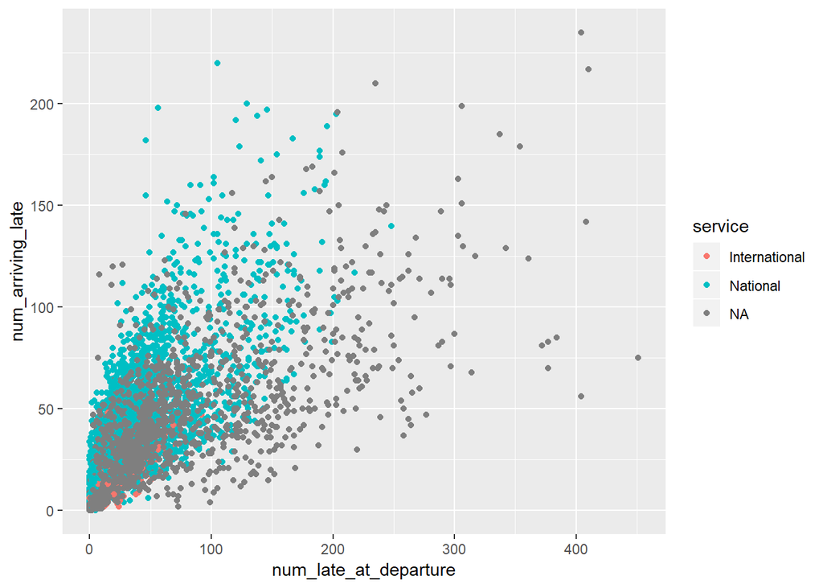

```r
ggplot(data = small_train) +
  geom_point(aes(x = num_late_at_departure, y = num_arriving_late, col = service))
```

## dplyr

### filter

2. Nuovamente importiamo i dati utilizzando il medesimo comando.

```r
small_train <- read_csv("https://raw.githubusercontent.com/rfordatascience/tidytuesday/master/data/2019/2019-02-26/small_trains.csv")
## Parsed with column specification:
## cols(
##   year = col_double(),
##   month = col_double(),
##   service = col_character(),
##   departure_station = col_character(),
##   arrival_station = col_character(),
##   journey_time_avg = col_double(),
##   total_num_trips = col_double(),
##   avg_delay_all_departing = col_double(),
##   avg_delay_all_arriving = col_double(),
##   num_late_at_departure = col_double(),
##   num_arriving_late = col_double(),
##   delay_cause = col_character(),
##   delayed_number = col_double()
## )
```

Se necessario caricate prima il pacchetto `readr`. Per applicare i *main verbs* di dplyr dobbiamo prima caricare il pacchetto.

```r
library("dplyr")
```

3. Selezionare tutte e sole le osservazioni per cui

A. Il numero di arrivi in ritardo in una tratta, codificato nella variabile num_arriving_late, è superiore a 100.

```r
filter(small_train, num_arriving_late > 100)
```

```
## # A tibble: 1,614 x 13
##     year month service departure_stati~ arrival_station journey_time_avg
##    <dbl> <dbl> <chr>   <chr>            <chr>                      <dbl>
##  1  2017     9 Nation~ LYON PART DIEU   PARIS LYON                 121.
##  2  2017     9 Nation~ BORDEAUX ST JEAN PARIS MONTPARN~            143.
##  3  2017     7 Nation~ BORDEAUX ST JEAN PARIS MONTPARN~            144.
##  4  2017     7 Nation~ PARIS MONTPARNA~ POITIERS                    94.3
##  5  2017    12 Nation~ BORDEAUX ST JEAN PARIS MONTPARN~            140.
##  6  2017    12 Nation~ LILLE            PARIS NORD                  63.3
##  7  2017    11 Nation~ BORDEAUX ST JEAN PARIS MONTPARN~            143.
##  8  2017    11 Nation~ LE MANS          PARIS MONTPARN~             56.2
##  9  2016    12 Nation~ LYON PART DIEU   MARSEILLE ST C~            105.
## 10  2017    12 Nation~ NANTES           PARIS MONTPARN~            129.
## # ... with 1,604 more rows, and 7 more variables: total_num_trips <dbl>,
## #   avg_delay_all_departing <dbl>, avg_delay_all_arriving <dbl>,
## #   num_late_at_departure <dbl>, num_arriving_late <dbl>,
## #   delay_cause <chr>, delayed_number <dbl>
```

B. Il numero di partenze in ritardo, codificato nella variabile num_late_at_departure, è inferiore a 50.

```r
filter(small_train, num_late_at_departure < 50)
```

```
## # A tibble: 24,138 x 13
##     year month service departure_stati~ arrival_station journey_time_avg
##    <dbl> <dbl> <chr>   <chr>            <chr>                      <dbl>
##  1  2017     9 Nation~ PARIS EST        METZ                        85.1
##  2  2017     9 Nation~ REIMS            PARIS EST                   47.1
##  3  2017     9 Nation~ PARIS EST        STRASBOURG                 116.
##  4  2017     9 Nation~ PARIS LYON       AVIGNON TGV                161.
##  5  2017     9 Nation~ PARIS LYON       BELLEGARDE (AI~            164.
##  6  2017     9 Nation~ PARIS LYON       BESANCON FRANC~            129.
##  7  2017     9 Nation~ CHAMBERY CHALLE~ PARIS LYON                 184.
##  8  2017     9 Nation~ PARIS LYON       GRENOBLE                   186.
##  9  2017     9 Nation~ PARIS LYON       MACON LOCHE                 97.4
## 10  2017     9 Nation~ PARIS LYON       MARSEILLE ST C~            198.
## # ... with 24,128 more rows, and 7 more variables: total_num_trips <dbl>,
## #   avg_delay_all_departing <dbl>, avg_delay_all_arriving <dbl>,
## #   num_late_at_departure <dbl>, num_arriving_late <dbl>,
## #   delay_cause <chr>, delayed_number <dbl>
```

C. La variabile serviceè pari a National oppure NA

```r
filter(small_train, service == "National" | is.na(service))
```

```
## # A tibble: 30,180 x 13
##     year month service departure_stati~ arrival_station journey_time_avg
##    <dbl> <dbl> <chr>   <chr>            <chr>                      <dbl>
##  1  2017     9 Nation~ PARIS EST        METZ                        85.1
##  2  2017     9 Nation~ REIMS            PARIS EST                   47.1
##  3  2017     9 Nation~ PARIS EST        STRASBOURG                 116.
##  4  2017     9 Nation~ PARIS LYON       AVIGNON TGV                161.
##  5  2017     9 Nation~ PARIS LYON       BELLEGARDE (AI~            164.
##  6  2017     9 Nation~ PARIS LYON       BESANCON FRANC~            129.
##  7  2017     9 Nation~ CHAMBERY CHALLE~ PARIS LYON                 184.
##  8  2017     9 Nation~ PARIS LYON       GRENOBLE                   186.
##  9  2017     9 Nation~ LYON PART DIEU   PARIS LYON                 121.
## 10  2017     9 Nation~ PARIS LYON       MACON LOCHE                 97.4
## # ... with 30,170 more rows, and 7 more variables: total_num_trips <dbl>,
## #   avg_delay_all_departing <dbl>, avg_delay_all_arriving <dbl>,
## #   num_late_at_departure <dbl>, num_arriving_late <dbl>,
## #   delay_cause <chr>, delayed_number <dbl>
```

D. La variabile month è minore di 4 oppure maggiore di 10.

```r
filter(small_train, month < 4 | month > 10)
```

```
## # A tibble: 13,200 x 13
##     year month service departure_stati~ arrival_station journey_time_avg
##    <dbl> <dbl> <chr>   <chr>            <chr>                      <dbl>
##  1  2017     1 Nation~ ANGERS SAINT LA~ PARIS MONTPARN~             96.6
##  2  2017     1 Nation~ DOUAI            PARIS NORD                  79.5
##  3  2017     1 Nation~ LYON PART DIEU   LILLE                      187.
##  4  2017     1 Nation~ MACON LOCHE      PARIS LYON                  98.9
##  5  2017     1 Nation~ MARSEILLE ST CH~ PARIS LYON                 201.
##  6  2017     1 Nation~ MARSEILLE ST CH~ LILLE                      300.
##  7  2017     1 Nation~ NANCY            PARIS EST                   93.8
##  8  2017     1 Nation~ PARIS EST        NANCY                       95.2
##  9  2017     1 Nation~ PARIS LYON       LE CREUSOT MON~             78.8
## 10  2017     1 Nation~ PARIS LYON       MACON LOCHE                 95.8
## # ... with 13,190 more rows, and 7 more variables: total_num_trips <dbl>,
## #   avg_delay_all_departing <dbl>, avg_delay_all_arriving <dbl>,
## #   num_late_at_departure <dbl>, num_arriving_late <dbl>,
## #   delay_cause <chr>, delayed_number <dbl>
```

E. Il ritardo medio per tutti i treni in partenza (codificato nella variabile avg_delay_all_departing) ed il ritardo medio per tutti i treni in arrivo (codificato nella variabile avg_delay_all_arriving) è inferiore, in valore assoluto, a 50.

```r
filter(small_train, abs(avg_delay_all_departing) < 50 , abs(avg_delay_all_arriving) < 50)
```

```
## # A tibble: 32,730 x 13
##     year month service departure_stati~ arrival_station journey_time_avg
##    <dbl> <dbl> <chr>   <chr>            <chr>                      <dbl>
##  1  2017     9 Nation~ PARIS EST        METZ                        85.1
##  2  2017     9 Nation~ REIMS            PARIS EST                   47.1
##  3  2017     9 Nation~ PARIS EST        STRASBOURG                 116.
##  4  2017     9 Nation~ PARIS LYON       AVIGNON TGV                161.
##  5  2017     9 Nation~ PARIS LYON       BELLEGARDE (AI~            164.
##  6  2017     9 Nation~ PARIS LYON       BESANCON FRANC~            129.
##  7  2017     9 Nation~ CHAMBERY CHALLE~ PARIS LYON                 184.
##  8  2017     9 Nation~ PARIS LYON       GRENOBLE                   186.
##  9  2017     9 Nation~ LYON PART DIEU   PARIS LYON                 121.
## 10  2017     9 Nation~ PARIS LYON       MACON LOCHE                 97.4
## # ... with 32,720 more rows, and 7 more variables: total_num_trips <dbl>,
## #   avg_delay_all_departing <dbl>, avg_delay_all_arriving <dbl>,
## #   num_late_at_departure <dbl>, num_arriving_late <dbl>,
## #   delay_cause <chr>, delayed_number <dbl>
```

### arrange

I primi due punti sono sempre uguali:

```r
small_train <- read_csv("https://raw.githubusercontent.com/rfordatascience/tidytuesday/master/data/2019/2019-02-26/small_trains.csv")
## Parsed with column specification:
## cols(
##   year = col_double(),
##   month = col_double(),
##   service = col_character(),
##   departure_station = col_character(),
##   arrival_station = col_character(),
##   journey_time_avg = col_double(),
##   total_num_trips = col_double(),
##   avg_delay_all_departing = col_double(),
##   avg_delay_all_arriving = col_double(),
##   num_late_at_departure = col_double(),
##   num_arriving_late = col_double(),
##   delay_cause = col_character(),
##   delayed_number = col_double()
## )
```

Se necessario caricate il pacchetto `dplyr`.

3. Quali sono le tratte con il maggior numero di minuti di ritardo? E quali quelle con il numero minore?

Se consideriamo il ritardo all’arrivo allora risulta:

```r
arrange(small_train, avg_delay_all_arriving)
```

```
## # A tibble: 32,772 x 13
##     year month service departure_stati~ arrival_station journey_time_avg
##    <dbl> <dbl> <chr>   <chr>            <chr>                      <dbl>
##  1  2016    12 Intern~ PARIS LYON       ITALIE                      290.
##  2  2016    12 Intern~ PARIS LYON       ITALIE                      290.
##  3  2016    12 Intern~ PARIS LYON       ITALIE                      290.
##  4  2016    12 Intern~ PARIS LYON       ITALIE                      290.
##  5  2016    12 Intern~ PARIS LYON       ITALIE                      290.
##  6  2016    12 Intern~ PARIS LYON       ITALIE                      290.
##  7  2017    11 Nation~ PARIS LYON       GRENOBLE                    184.
##  8  2017    11 Nation~ PARIS LYON       GRENOBLE                    184.
##  9  2017    11 Nation~ PARIS LYON       GRENOBLE                    184.
## 10  2017    11 Nation~ PARIS LYON       GRENOBLE                    184.
## # ... with 32,762 more rows, and 7 more variables: total_num_trips <dbl>,
## #   avg_delay_all_departing <dbl>, avg_delay_all_arriving <dbl>,
## #   num_late_at_departure <dbl>, num_arriving_late <dbl>,
## #   delay_cause <chr>, delayed_number <dbl>
```

```r
arrange(small_train, desc(avg_delay_all_arriving))
```

```
## # A tibble: 32,772 x 13
##     year month service departure_stati~ arrival_station journey_time_avg
##    <dbl> <dbl> <chr>   <chr>            <chr>                      <dbl>
##  1  2018     7 <NA>    LYON PART DIEU   RENNES                      235.
##  2  2018     7 <NA>    LYON PART DIEU   RENNES                      235.
##  3  2018     7 <NA>    LYON PART DIEU   RENNES                      235.
##  4  2018     7 <NA>    LYON PART DIEU   RENNES                      235.
##  5  2018     7 <NA>    LYON PART DIEU   RENNES                      235.
##  6  2018     7 <NA>    LYON PART DIEU   RENNES                      235.
##  7  2018     6 <NA>    PARIS LYON       ITALIE                      262.
##  8  2018     6 <NA>    PARIS LYON       ITALIE                      262.
##  9  2018     6 <NA>    PARIS LYON       ITALIE                      262.
## 10  2018     6 <NA>    PARIS LYON       ITALIE                      262.
## # ... with 32,762 more rows, and 7 more variables: total_num_trips <dbl>,
## #   avg_delay_all_departing <dbl>, avg_delay_all_arriving <dbl>,
## #   num_late_at_departure <dbl>, num_arriving_late <dbl>,
## #   delay_cause <chr>, delayed_number <dbl>
```

4. Quali sono le tratte più frequentate? E quelle meno frequentate? E quelle con il maggiore numero di treni in ritardo?

Le tratte più frequentate sono

```r
arrange(small_train, desc(total_num_trips))
```

```
## # A tibble: 32,772 x 13
##     year month service departure_stati~ arrival_station journey_time_avg
##    <dbl> <dbl> <chr>   <chr>            <chr>                      <dbl>
##  1  2018     3 <NA>    BORDEAUX ST JEAN PARIS MONTPARN~             141.
##  2  2018     3 <NA>    BORDEAUX ST JEAN PARIS MONTPARN~             141.
##  3  2018     3 <NA>    BORDEAUX ST JEAN PARIS MONTPARN~             141.
##  4  2018     3 <NA>    BORDEAUX ST JEAN PARIS MONTPARN~             141.
##  5  2018     3 <NA>    BORDEAUX ST JEAN PARIS MONTPARN~             141.
##  6  2018     3 <NA>    BORDEAUX ST JEAN PARIS MONTPARN~             141.
##  7  2017    12 Nation~ BORDEAUX ST JEAN PARIS MONTPARN~             140.
##  8  2017    12 Nation~ BORDEAUX ST JEAN PARIS MONTPARN~             140.
##  9  2017    12 Nation~ BORDEAUX ST JEAN PARIS MONTPARN~             140.
## 10  2017    12 Nation~ BORDEAUX ST JEAN PARIS MONTPARN~             140.
## # ... with 32,762 more rows, and 7 more variables: total_num_trips <dbl>,
## #   avg_delay_all_departing <dbl>, avg_delay_all_arriving <dbl>,
## #   num_late_at_departure <dbl>, num_arriving_late <dbl>,
## #   delay_cause <chr>, delayed_number <dbl>
```

e quelle meno frequentate sono

```r
arrange(small_train, total_num_trips)
```

```
## # A tibble: 32,772 x 13
##     year month service departure_stati~ arrival_station journey_time_avg
##    <dbl> <dbl> <chr>   <chr>            <chr>                      <dbl>
##  1  2018     8 <NA>    TOURCOING        BORDEAUX ST JE~             280.
##  2  2018     8 <NA>    TOURCOING        BORDEAUX ST JE~             280.
##  3  2018     8 <NA>    TOURCOING        BORDEAUX ST JE~             280.
##  4  2018     8 <NA>    TOURCOING        BORDEAUX ST JE~             280.
##  5  2018     8 <NA>    TOURCOING        BORDEAUX ST JE~             280.
##  6  2018     8 <NA>    TOURCOING        BORDEAUX ST JE~             280.
##  7  2018     8 <NA>    BORDEAUX ST JEAN TOURCOING                   293.
##  8  2018     8 <NA>    BORDEAUX ST JEAN TOURCOING                   293.
##  9  2018     8 <NA>    BORDEAUX ST JEAN TOURCOING                   293.
## 10  2018     8 <NA>    BORDEAUX ST JEAN TOURCOING                   293.
## # ... with 32,762 more rows, and 7 more variables: total_num_trips <dbl>,
## #   avg_delay_all_departing <dbl>, avg_delay_all_arriving <dbl>,
## #   num_late_at_departure <dbl>, num_arriving_late <dbl>,
## #   delay_cause <chr>, delayed_number <dbl>
```

Le tratte con il maggior numero di treni in ritardo (sempre all’arrivo) sono:

```r
arrange(small_train, desc(num_arriving_late))
```

```
## # A tibble: 32,772 x 13
##     year month service departure_stati~ arrival_station journey_time_avg
##    <dbl> <dbl> <chr>   <chr>            <chr>                      <dbl>
##  1  2018     7 <NA>    LYON PART DIEU   MARSEILLE ST C~             105.
##  2  2018     7 <NA>    LYON PART DIEU   MARSEILLE ST C~             105.
##  3  2018     7 <NA>    LYON PART DIEU   MARSEILLE ST C~             105.
##  4  2018     7 <NA>    LYON PART DIEU   MARSEILLE ST C~             105.
##  5  2018     7 <NA>    LYON PART DIEU   MARSEILLE ST C~             105.
##  6  2018     7 <NA>    LYON PART DIEU   MARSEILLE ST C~             105.
##  7  2015     7 Nation~ MARSEILLE ST CH~ LYON PART DIEU              101.
##  8  2015     7 Nation~ MARSEILLE ST CH~ LYON PART DIEU              101.
##  9  2015     7 Nation~ MARSEILLE ST CH~ LYON PART DIEU              101.
## 10  2015     7 Nation~ MARSEILLE ST CH~ LYON PART DIEU              101.
## # ... with 32,762 more rows, and 7 more variables: total_num_trips <dbl>,
## #   avg_delay_all_departing <dbl>, avg_delay_all_arriving <dbl>,
## #   num_late_at_departure <dbl>, num_arriving_late <dbl>,
## #   delay_cause <chr>, delayed_number <dbl>
```

### select

I primi due punti sono sempre uguali:

```r
small_train <- read_csv("https://raw.githubusercontent.com/rfordatascience/tidytuesday/master/data/2019/2019-02-26/small_trains.csv")
## Parsed with column specification:
## cols(
##   year = col_double(),
##   month = col_double(),
##   service = col_character(),
##   departure_station = col_character(),
##   arrival_station = col_character(),
##   journey_time_avg = col_double(),
##   total_num_trips = col_double(),
##   avg_delay_all_departing = col_double(),
##   avg_delay_all_arriving = col_double(),
##   num_late_at_departure = col_double(),
##   num_arriving_late = col_double(),
##   delay_cause = col_character(),
##   delayed_number = col_double()
## )
```

Se necessario caricate il pacchetto `dplyr`.

3. Selezioniamo unicamente le variabili `total_num_trips` e `delay_cause`.

```r
select(small_train, total_num_trips, delay_cause)
```

```
## # A tibble: 32,772 x 2
##    total_num_trips delay_cause
##              <dbl> <chr>
##  1             299 delay_cause_external_cause
##  2             218 delay_cause_external_cause
##  3             333 delay_cause_external_cause
##  4             481 delay_cause_external_cause
##  5             190 delay_cause_external_cause
##  6             191 delay_cause_external_cause
##  7             208 delay_cause_external_cause
##  8             216 delay_cause_external_cause
##  9             661 delay_cause_external_cause
## 10             201 delay_cause_external_cause
## # ... with 32,762 more rows
```

4. Selezionare unicamente le variabili che iniziano con la stringa avg, le variabili che terminano con la stringa station e le variabili che contengono la stringa num.

```r
select(small_train, starts_with("avg"), ends_with("station"), contains("num"))
```

```
## # A tibble: 32,772 x 8
##    avg_delay_all_d~ avg_delay_all_a~ departure_stati~ arrival_station
##               <dbl>            <dbl> <chr>            <chr>
##  1            0.752            0.420 PARIS EST        METZ
##  2            1.26             1.14  REIMS            PARIS EST
##  3            1.14             1.59  PARIS EST        STRASBOURG
##  4            1.41             4.79  PARIS LYON       AVIGNON TGV
##  5            1.73             6.01  PARIS LYON       BELLEGARDE (AI~
##  6            1.84             5.03  PARIS LYON       BESANCON FRANC~
##  7            3.82             6.45  CHAMBERY CHALLE~ PARIS LYON
##  8            2.21             6.58  PARIS LYON       GRENOBLE
##  9            3.90             5.35  LYON PART DIEU   PARIS LYON
## 10            2.14             5.14  PARIS LYON       MACON LOCHE
## # ... with 32,762 more rows, and 4 more variables: total_num_trips <dbl>,
## #   num_late_at_departure <dbl>, num_arriving_late <dbl>,
## #   delayed_number <dbl>
```

### mutate

Nuovamente i primi due punti dell’esercizio sono sempre uguali.

```r
small_train <- read_csv("https://raw.githubusercontent.com/rfordatascience/tidytuesday/master/data/2019/2019-02-26/small_trains.csv")
## Parsed with column specification:
## cols(
##   year = col_double(),
##   month = col_double(),
##   service = col_character(),
##   departure_station = col_character(),
##   arrival_station = col_character(),
##   journey_time_avg = col_double(),
##   total_num_trips = col_double(),
##   avg_delay_all_departing = col_double(),
##   avg_delay_all_arriving = col_double(),
##   num_late_at_departure = col_double(),
##   num_arriving_late = col_double(),
##   delay_cause = col_character(),
##   delayed_number = col_double()
## )
```

Se necessario caricate il pacchetto `dplyr`.

Creiamo ora diverse nuove variabili:

A. La differenza tra il ritardo medio alla partenza ed il ritardo medio all’arrivo.

```r
mutate(small_train, trip_gain = avg_delay_all_arriving - avg_delay_all_departing)
```

```
## # A tibble: 32,772 x 14
##     year month service departure_stati~ arrival_station journey_time_avg
##    <dbl> <dbl> <chr>   <chr>            <chr>                      <dbl>
##  1  2017     9 Nation~ PARIS EST        METZ                        85.1
##  2  2017     9 Nation~ REIMS            PARIS EST                   47.1
##  3  2017     9 Nation~ PARIS EST        STRASBOURG                 116.
##  4  2017     9 Nation~ PARIS LYON       AVIGNON TGV                161.
##  5  2017     9 Nation~ PARIS LYON       BELLEGARDE (AI~            164.
##  6  2017     9 Nation~ PARIS LYON       BESANCON FRANC~            129.
##  7  2017     9 Nation~ CHAMBERY CHALLE~ PARIS LYON                 184.
##  8  2017     9 Nation~ PARIS LYON       GRENOBLE                   186.
##  9  2017     9 Nation~ LYON PART DIEU   PARIS LYON                 121.
## 10  2017     9 Nation~ PARIS LYON       MACON LOCHE                 97.4
## # ... with 32,762 more rows, and 8 more variables: total_num_trips <dbl>,
## #   avg_delay_all_departing <dbl>, avg_delay_all_arriving <dbl>,
## #   num_late_at_departure <dbl>, num_arriving_late <dbl>,
## #   delay_cause <chr>, delayed_number <dbl>, trip_gain <dbl>
```

B. La differenza tra il numero di treni arrivati in orario ed il numero di treni partiti in ritardo;

```r
mutate(small_train,
       num_treni_arrivati_in_orario = total_num_trips - num_arriving_late,
       diff = num_treni_arrivati_in_orario - num_late_at_departure )
```

```
## # A tibble: 32,772 x 15
##     year month service departure_stati~ arrival_station journey_time_avg
##    <dbl> <dbl> <chr>   <chr>            <chr>                      <dbl>
##  1  2017     9 Nation~ PARIS EST        METZ                        85.1
##  2  2017     9 Nation~ REIMS            PARIS EST                   47.1
##  3  2017     9 Nation~ PARIS EST        STRASBOURG                 116.
##  4  2017     9 Nation~ PARIS LYON       AVIGNON TGV                161.
##  5  2017     9 Nation~ PARIS LYON       BELLEGARDE (AI~            164.
##  6  2017     9 Nation~ PARIS LYON       BESANCON FRANC~            129.
##  7  2017     9 Nation~ CHAMBERY CHALLE~ PARIS LYON                 184.
##  8  2017     9 Nation~ PARIS LYON       GRENOBLE                   186.
##  9  2017     9 Nation~ LYON PART DIEU   PARIS LYON                 121.
## 10  2017     9 Nation~ PARIS LYON       MACON LOCHE                 97.4
## # ... with 32,762 more rows, and 9 more variables: total_num_trips <dbl>,
## #   avg_delay_all_departing <dbl>, avg_delay_all_arriving <dbl>,
## #   num_late_at_departure <dbl>, num_arriving_late <dbl>,
## #   delay_cause <chr>, delayed_number <dbl>,
## #   num_treni_arrivati_in_orario <dbl>, diff <dbl>
```

C. Una stringa di testo che concatena la stazione di partenza e la stazione di arrivo (Suggerimento: Leggere l’help della funzione paste())

```r
mutate(small_train,
       route = paste(departure_station, arrival_station, sep = " - "))
```

```
## # A tibble: 32,772 x 14
##     year month service departure_stati~ arrival_station journey_time_avg
##    <dbl> <dbl> <chr>   <chr>            <chr>                      <dbl>
##  1  2017     9 Nation~ PARIS EST        METZ                        85.1
##  2  2017     9 Nation~ REIMS            PARIS EST                   47.1
##  3  2017     9 Nation~ PARIS EST        STRASBOURG                 116.
##  4  2017     9 Nation~ PARIS LYON       AVIGNON TGV                161.
##  5  2017     9 Nation~ PARIS LYON       BELLEGARDE (AI~            164.
##  6  2017     9 Nation~ PARIS LYON       BESANCON FRANC~            129.
##  7  2017     9 Nation~ CHAMBERY CHALLE~ PARIS LYON                 184.
##  8  2017     9 Nation~ PARIS LYON       GRENOBLE                   186.
##  9  2017     9 Nation~ LYON PART DIEU   PARIS LYON                 121.
## 10  2017     9 Nation~ PARIS LYON       MACON LOCHE                 97.4
## # ... with 32,762 more rows, and 8 more variables: total_num_trips <dbl>,
## #   avg_delay_all_departing <dbl>, avg_delay_all_arriving <dbl>,
## #   num_late_at_departure <dbl>, num_arriving_late <dbl>,
## #   delay_cause <chr>, delayed_number <dbl>, route <chr>
```

### summarize

Nuovamente i primi due punti dell’esercizio sono sempre uguali.

```r
small_train <- read_csv("https://raw.githubusercontent.com/rfordatascience/tidytuesday/master/data/2019/2019-02-26/small_trains.csv")
## Parsed with column specification:
## cols(
##   year = col_double(),
##   month = col_double(),
##   service = col_character(),
##   departure_station = col_character(),
##   arrival_station = col_character(),
##   journey_time_avg = col_double(),
##   total_num_trips = col_double(),
##   avg_delay_all_departing = col_double(),
##   avg_delay_all_arriving = col_double(),
##   num_late_at_departure = col_double(),
##   num_arriving_late = col_double(),
##   delay_cause = col_character(),
##   delayed_number = col_double()
## )
```

Se necessario caricate il pacchetto `dplyr`.

3. Calcolare il numero medio di treni arrivati in ritardo ed il numero medio di treni partiti in ritardo.

```r
summarize(small_train, mean_num_late_departure = mean(num_late_at_departure), mean_num_arriving_late = mean(num_arriving_late))
```

```
## # A tibble: 1 x 2
##   mean_num_late_departure mean_num_arriving_late
##                     <dbl>                  <dbl>
## 1                    41.6                     NA
```

Il valore di NA su `mean_num_arriving_late` è dovuto ad uno o più valori NA nella variabile. Possiamo risolvere il problema utilizzando l’opzione `na.rm = TRUE` della funzione `mean`.

```r
summarize(small_train, mean_num_late_departure = mean(num_late_at_departure), mean_num_arriving_late = mean(num_arriving_late, na.rm = TRUE))
```

```
## # A tibble: 1 x 2
##   mean_num_late_departure mean_num_arriving_late
##                     <dbl>                  <dbl>
## 1                    41.6                   38.0
```

Naturalmente bisognerebbe indagare sul significato di quei valori NA.

4. Calcolare il numero mediano di treni partiti in ritardo stratificando per stazione di partenza.

```r
grouped_by_dep_st <- group_by(small_train, departure_station)
summarize(grouped_by_dep_st, median_late_departure = median(num_late_at_departure))
```

```
## # A tibble: 59 x 2
##    departure_station          median_late_departure
##    <chr>                                      <dbl>
##  1 AIX EN PROVENCE TGV                           55
##  2 ANGERS SAINT LAUD                             54
##  3 ANGOULEME                                     74
##  4 ANNECY                                         5
##  5 ARRAS                                         37
##  6 AVIGNON TGV                                  119
##  7 BARCELONA                                     23
##  8 BELLEGARDE (AIN)                              38
##  9 BESANCON FRANCHE COMTE TGV                     9
## 10 BORDEAUX ST JEAN                             104
## # ... with 49 more rows
```

5. Si calcoli il numero massimo di treni partiti in ritardo stratificando per la stazione di partenza e considerando solo le tratte avvenute nel mese di aprile. Si ordini il datasetrispetto al valore massimo (cioè la variabile appena creata) e si salvi il risultati in un dataframechiamato my_first_EDA.

Innanzitutto filtriamo i viaggi avvenuti in aprile

```r
small_train_april <- filter(small_train, month == 4)
```

Raggruppiamo il dataset e calcoliamo le statistiche di sintesi.

```r
grouped_by_dep_st_aprile <- group_by(small_train_april, departure_station)
my_first_EDA <- summarize(grouped_by_dep_st_aprile, max_late_departure = max(num_late_at_departure))
```

Ordiniamo il dataset

```r
arrange(my_first_EDA, max_late_departure)
```

```
## # A tibble: 59 x 2
##    departure_station          max_late_departure
##    <chr>                                   <dbl>
##  1 MADRID                                      3
##  2 PARIS VAUGIRARD                             4
##  3 TOURCOING                                   5
##  4 BREST                                       7
##  5 BARCELONA                                   8
##  6 SAINT ETIENNE CHATEAUCREUX                  8
##  7 DUNKERQUE                                  11
##  8 LA ROCHELLE VILLE                          11
##  9 ST MALO                                    11
## 10 ANNECY                                     12
## # ... with 49 more rows
```

6. Stampiamolo a schermo

```r
my_first_EDA
```

```
## # A tibble: 59 x 2
##    departure_station          max_late_departure
##    <chr>                                   <dbl>
##  1 AIX EN PROVENCE TGV                       128
##  2 ANGERS SAINT LAUD                         139
##  3 ANGOULEME                                 117
##  4 ANNECY                                     12
##  5 ARRAS                                     100
##  6 AVIGNON TGV                               160
##  7 BARCELONA                                   8
##  8 BELLEGARDE (AIN)                           48
##  9 BESANCON FRANCHE COMTE TGV                 32
## 10 BORDEAUX ST JEAN                          200
## # ... with 49 more rows
```

7. Creiamo un grafico opportuno

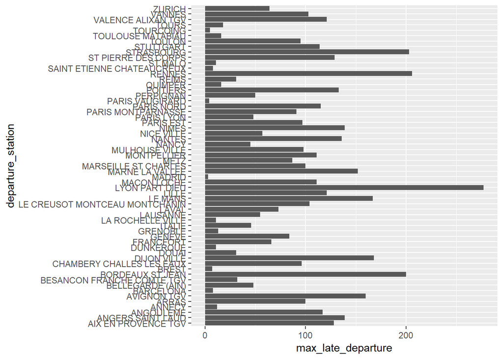

```r
ggplot(data = my_first_EDA) +
  geom_col(aes(x = departure_station, y = max_late_departure)) +
  coord_flip()
```